# Chapter 13 Practice

Pablo Bello

2023-02-03

### Chapter 13 SR Homework

#### 13E1

If the tank intercept in the model is $\bar{\alpha} + \alpha_{TANK[i]} \sigma$, then prior for $\alpha_{TANK}$ with the smallest standard deviation will produce the most shrinkage as it places less confidence on finding tank intercepts with large deviations from the grand mean. The relationship is not as straightforward as it may seem though, since we look at shrinkage in the probability scale, whilst those priors are in log-odds. So in order to know how much weight the prior puts into extreme values we need to do the inverse logit transform. Because of this transformation, both the mean and the standard distribution of the prior affect the how the density of extreme values in the probability scale.

```r
library(tidyverse)
library(ggh4x)
library(ggpubr)
theme_set(theme_pubr(border = TRUE))
```

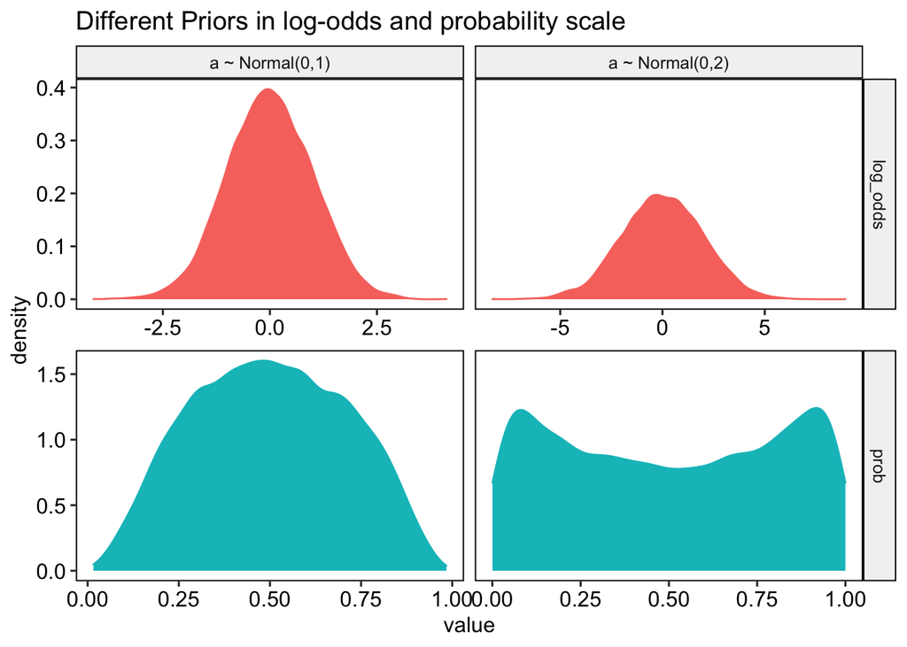

```r
tibble("a ~ Normal(0,1)" = rnorm(1e4,0,1),
         "a ~ Normal(0,2)" = rnorm(1e4,0,2)) |>
  pivot_longer(cols = everything(),values_to = "log_odds") |>
  mutate(prob = exp(log_odds)/(1 + exp(log_odds))) |>
  pivot_longer(cols = c(log_odds,prob), names_to = "scale", values_to = "value") |>
  ggplot(aes(value, group = name, fill = scale, color = scale)) +
  geom_density() +
  #facet_grid(vars(scale), vars(name),scales = "free") +
  facet_grid2(vars(scale), vars(name),scales = "free",independent = "x") +

  labs(title = "Different Priors in log-odds and probability scale") +
  theme(legend.position = "none")
```

#### 13E2

The original version:
$$\begin{aligned}
y_i &\sim \textrm{Binomial}(1,p_i) \\
logit(p_i) &= \alpha_{GROUP[i]} + \beta x_i \\
\alpha_{GROUP} &\sim \textrm{Normal}(0,1.5) \\
\beta &\sim \textrm{Normal}(0,0.5) \\
\end{aligned}$$

A varying intercepts with partial pooling version:

$$\begin{aligned}
y_i &\sim \textrm{Binomial}(1,p_i) \\
logit(p_i) &= \alpha_{GROUP[i]} + \beta x_i \\
\alpha_{GROUP} &\sim \textrm{Normal}(\bar{\alpha},\sigma) \\
\beta &\sim \textrm{Normal}(0,0.5) \\
\bar{\alpha} &\sim \textrm{Normal}(0,1) \\
\sigma &\sim \textrm{Exponential}(1)
\end{aligned}$$

#### 13E3

$$\begin{aligned}
y_i &\sim \textrm{Normal}(\mu_i,\sigma) \\
\mu_i &= \alpha_{GROUP[i]} + \beta x_i \\
\alpha_{GROUP} &\sim \textrm{Normal}(0,1) \\
\beta &\sim \textrm{Normal}(0,1) \\
\sigma &\sim \textrm{Exponential}(1)
\end{aligned}$$

Varying intercepts with non-centered parametrization:

$$\begin{aligned}
y_i &\sim \textrm{Normal}(\mu_i,\sigma) \\
\mu_i &= \bar{\alpha} + z_{GROUP[i]} \sigma_{\alpha} + \beta x_i \\
\bar{\alpha} &\sim \textrm{Normal}(0,1) \\
z_{GROUP} &\sim \textrm{Normal}(0,1) \\
\beta &\sim \textrm{Normal(0,1)} \\
\sigma &\sim \textrm{Exponential}(1) \\
\sigma_{\alpha} &\sim \textrm{Exponential}(1)
\end{aligned}$$

#### 13E4

In a dataset of researchers, where $A$ is the number of papers they got accepted in the last year, $UNI$ is the university they are associated we can do the following model:

$$\begin{aligned}
A_i &\sim \textrm{Poisson}(\lambda_i) \\
log(\lambda_i) &= \bar{\alpha} + z_{UNI[i]} \sigma_{\alpha}\\
\bar{\alpha} &\sim \textrm{Normal}(0,1) \\
z_{j} &\sim \textrm{Normal}(0,1) \\
\sigma_{\alpha} &\sim \textrm{Exponential}(1) \\
\end{aligned}$$

#### 13E5

If we now include in the model the field a researcher is working in ($FIELD$) we get:

$$\begin{aligned}
A_i &\sim \textrm{Poisson}(\lambda_i) \\
log(\lambda_i) &= \bar{\alpha} + z_{UNI[i]} \sigma_{\alpha} +
x_{FIELD[i]}\sigma_{\gamma} \\
\bar{\alpha} &\sim \textrm{Normal}(0,1) \\
z_{j} &\sim \textrm{Normal}(0,1) \\
x_{j} &\sim \textrm{Normal}(0,1) \\
\sigma_{\alpha} &\sim \textrm{Exponential}(1) \\
\sigma_{\gamma} &\sim \textrm{Exponential}(1)
\end{aligned}$$
Which is a cross-classified varying intercepts model as there is researches of different disciplines within the same university.

#### 13M1

```r
###--- Libraries
library(tidyverse)
library(brms)
library(rethinking)
library(ggpubr)
library(janitor)
library(rstan)
library(glue)
library(kableExtra)
source("week_3/helper_functions.R")
```

```r
###--- Load the data
data(reedfrogs)

tbl <-
  reedfrogs |>
  as_tibble() |>
  mutate(tank = row_number(),
         pred = ifelse(pred == "no","no_pred","pred")) |>
  mutate(inter = paste0(pred,"_",size))
```

```r
###--- Model Formulas and Priors


  ###--- Only intercept
  formula_m1 <- bf(surv | trials(density) ~ 1 + (1 | tank))
  priors_m1 <- c(prior(normal(0,1.5) , class = Intercept),
                 prior(exponential(1), class = sd))

  ###--- With Pred
  formula_m2 <- bf(surv | trials(density) ~ 1 + (1 | tank) + pred)

  ###--- With size
  formula_m3 <- bf(surv | trials(density) ~ 1 + (1 | tank) + size)

  ###--- With pred and size
  formula_m4 <- bf(surv | trials(density) ~ 1 + (1 | tank) + pred + size)

  ###--- With pred and size and their interaction
  formula_m5 <- bf(surv | trials(density) ~ 1 + (1 | tank) + pred + size + inter)

  ###--- Priors for models 2:5
  priors_w_beta <- c(prior(normal(0,.2) , class = Intercept),
                 prior(exponential(1), class = sd),
                 prior(normal(0, 1.5), class = b))
```

```r
formulas <- list(
  "only_intercept" = formula_m1,
  "predator" = formula_m2,
  "size" = formula_m3,
  "predator + size" = formula_m4,
  "interaction" = formula_m5)

m <- list()
sd <- list()

###--- Fit the baseline model
m[[1]] <-
  brm(formula = formula_m1,
      data = tbl,
      family = "binomial",
      prior = priors_m1,
      file = "fits/ch13_m2",
      sample_prior = "yes",
      file_refit = "on_change")


sd[[1]] <- extract_intercept_sd(m[[1]])

###--- Update it

for(i in 2:length(formulas)) {

  m[[i]] <-
    brm(formula = formulas[[i]],
      data = tbl,
      family = "binomial",
      prior = priors_m1,
      file = glue("fits/ch13_m2_{i}"),
      sample_prior = "yes",
      file_refit = "on_change")

  sd[[i]] <- extract_intercept_sd(m[[i]])

}


names(sd) <- names(formulas)
res <- bind_rows(sd,.id = "model")
```

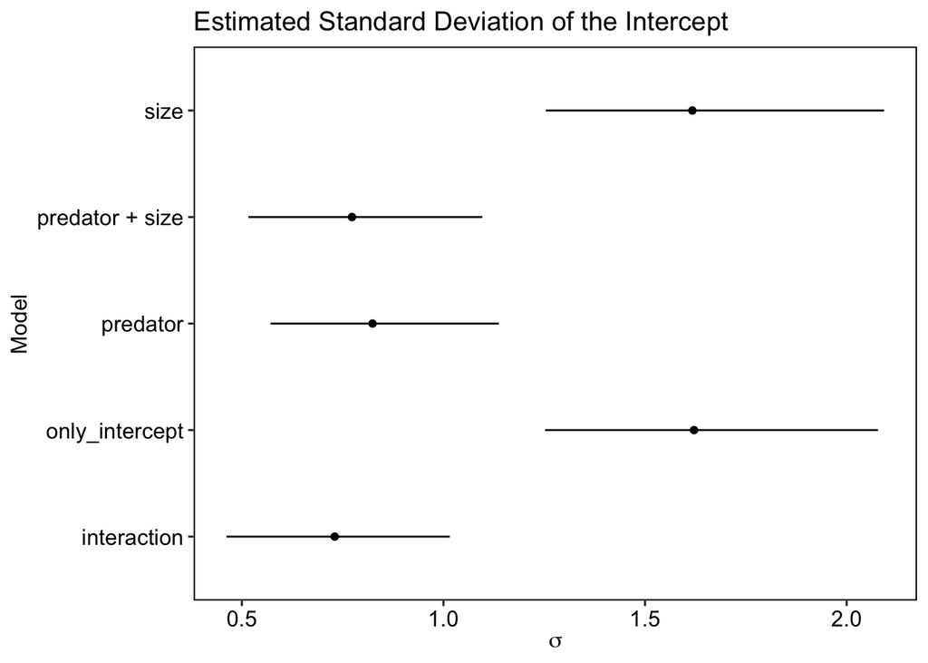

```r
###--- Plot the results

res |>
  ggplot(aes(estimate, model)) +
  geom_point() +
  geom_linerange(aes(xmin = q2_5, xmax = q97_5)) +
  labs(x = expression(sigma),
       y = "Model",
       title = "Estimated Standard Deviation of the Intercept")
```

The predicted variation across tanks is smaller when predators are included in the model, whilst tank size does not affect it. So conditioning on the presence of predators in the tanks reduces the variation in survival rates across tanks, which makes sense given that predators predate.

#### 13M2

```r
waic <- list()

for(i in 1:length(m)) {

  waic[[i]] <- add_criterion(m[[i]], "waic")


}

w <- loo_compare(waic[[1]],
                 waic[[2]],
                 waic[[3]],
                 waic[[4]],
                 waic[[5]],
                 criterion = "waic")


w <-
  print(w, simplify = F) |>
  as_tibble() |>
  mutate(model = names(sd)) |>
  relocate(model)

w <-
  w |>
  mutate(across(2:ncol(w),round,2))
```

```r
###--- Present the results
w |>
  kable(format = "html",digits = 2) |>
  kable_styling()
```

| model | elpd_diff | se_diff | elpd_waic | se_elpd_waic | p_waic | se_p_waic | waic | se_waic |
| --- | --- | --- | --- | --- | --- | --- | --- | --- |
| only_intercept | 0.00 | 0.00 | -99.82 | 3.61 | 20.64 | 0.85 | 199.65 | 7.22 |
| predator | -0.09 | 3.20 | -99.91 | 4.73 | 19.54 | 2.09 | 199.82 | 9.46 |
| size | -0.34 | 0.41 | -100.16 | 3.73 | 21.10 | 0.89 | 200.32 | 7.45 |
| predator + size | -0.90 | 3.86 | -100.72 | 5.17 | 18.92 | 2.57 | 201.45 | 10.33 |
| interaction | -0.91 | 3.13 | -100.74 | 4.56 | 19.74 | 2.00 | 201.47 | 9.12 |

There are no big differences in WAIC scores, although based on the posterior I would have expected the model with predator as the only predictor to have lower deviance.

```r
###--- WAIC weights
w_w <- model_weights(waic[[1]],
              waic[[2]],
              waic[[3]],
              waic[[4]],
              waic[[5]],
              weights = "waic") %>%
  round(digits = 3)
names(w_w) <- names(sd)


w_w |>
  as_tibble(rownames = "model") |>
  rename(waic_weight = value) |>
  kable(format = "html",digits = 2) |>
  kable_styling()
```

[output not shown]

#### 13M4

You can’t do a cauchy on that prior in brms so I will use ulam.

```r
###--- Model with Cauchy pop-level RE

data <- list(tank = tbl$tank,
             S = tbl$surv,
             N = tbl$density)
m_c <-
  ulam(
    alist(
      S ~ dbinom(N,p),
      logit(p) <- a[tank],
      a[tank] ~ dcauchy(a_bar,sigma),
      a_bar ~ dnorm(0,1.5),
      sigma ~ dexp(1)),
    data = data,
    chains = 4,
    log_lik = TRUE)

###--- Extract coefficients
coef_m_c <- precis(m_c,depth = 2,prob = .95)


###--- Put them in a tibble
coefs_m_cauchy <-
  bind_cols(coef_m_c[1:6])  |>
    as_tibble() |>
    clean_names() |>
    mutate(tank = row.names(coef_m_c)) |>
  filter(str_detect(tank, "[1-9]+") == TRUE) |>  # Filter tank intercetps
  mutate(tank = as.integer(str_remove_all(tank,"\\[|\\]|a"))) |>
  rename(low_95 = x2_5_percent, high_95 = x97_5_percent)
```

```r
###-- Extract params from model with gaussian dist
coefs_m_normal <-
  coef(m[[1]])[["tank"]]|>
  as_tibble() |>
  clean_names() |>
  rename(mean = estimate_intercept,
         sd = est_error_intercept,
         low_95 = q2_5_intercept,
         high_95 = q97_5_intercept) |>
  mutate(tank = row_number())
```

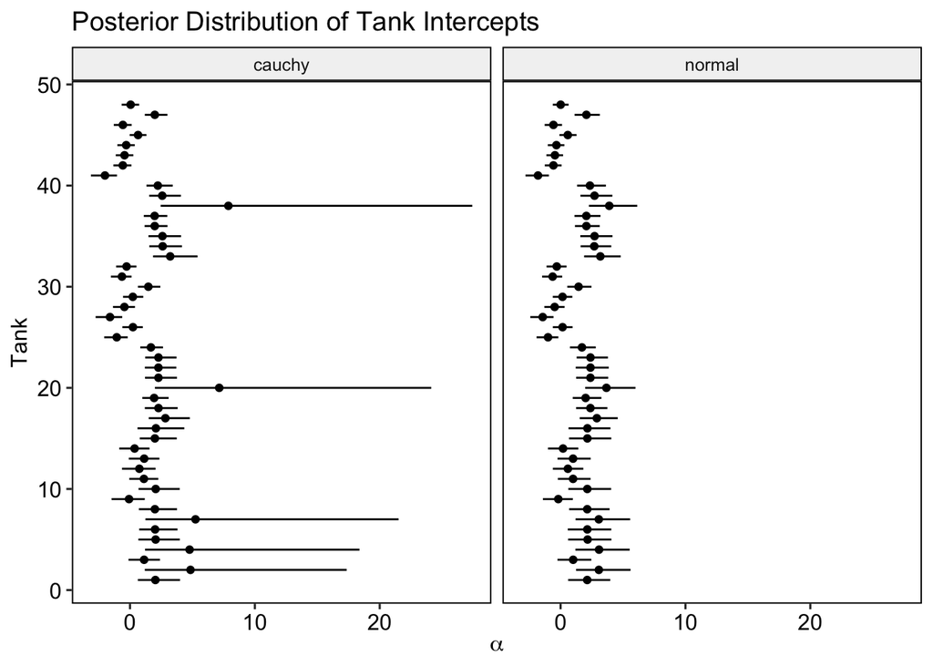

```r
###-- Put them together
res <-
  bind_rows("cauchy" = coefs_m_cauchy,
          "normal" = coefs_m_normal,.id = "prior")

###-- Plot
res |>
  ggplot(aes(mean, tank)) +
  geom_point() +
  geom_linerange(aes(xmin = low_95, xmax = high_95)) +
  labs(title = "Posterior Distribution of Tank Intercepts",
       x = expression(alpha),
       y = "Tank") +
  facet_wrap(~ prior)
```

Comparing the two models, the one with a Cauchy distribution for the intercepts results in crazy confidence intervals and higher means for some of the tanks. My guess as to why this happens is the following. It can be sensible to use Cauchy prior, for instance, Gelman et al (2008) recommend Cauchy(0,2.5) as a weekly informative prior for logistic regression with scale independent variables(mean = 0, sd = .5). In this set-up the dispersion parameter of the Cauchy distribution comes from an exponential function with rate 1, which is likely to produce values higher than 2.5. In other words, a high sd for the Cauchy distribution might be messing up the exploration of the posterior by creating very steep regions and assigning a high prior likelihood to large differences between the grand mean and the individual intercepts.

```r
###--- Increase the target acceptance rate
m_c2 <-
  ulam(
    alist(
      S ~ dbinom(N,p),
      logit(p) <- a[tank],
      a[tank] ~ dcauchy(a_bar,sigma),
      a_bar ~ dnorm(0,1.5),
      sigma ~ dexp(1)),
    data = data,
    chains = 4,
    log_lik = TRUE,
    control=list(adapt_delta=0.99))
```

Still about the same number of divergent transitions.

```r
###--- Non-centered parametrization
m_c3 <-
  ulam(
    alist(
      S ~ dbinom(N,p),
      logit(p) <- a_bar + z[tank]*sigma,
      z[tank] ~ dcauchy(0,1),
      a_bar ~ dnorm(0,1.5),
      sigma ~ dexp(1)),
    data = data,
    chains = 4,
    log_lik = TRUE,
    control=list(adapt_delta=0.95))
```

And still a lot of divergent transitions.

### 13M5

```r
###--- Student-t distribution of pop RE
formula_m_student <- bf(surv | trials(density) ~ 1 + (1 | gr(tank, dist = "student")))

m_student <-
  brm(formula = formula_m_student,
    data = tbl,
    family = "binomial",
    prior = priors_m1,
    file = "fits/ch13_m2_student",
    sample_prior = "yes",
    file_refit = "on_change",
    control = list(adapt_delta = 0.9))

###-- Extract params from model with student dist
coefs_m_student <-
  coef(m_student)[["tank"]]|>
  as_tibble() |>
  clean_names() |>
  rename(mean = estimate_intercept,
         sd = est_error_intercept,
         low_95 = q2_5_intercept,
         high_95 = q97_5_intercept) |>
  mutate(tank = row_number())
```

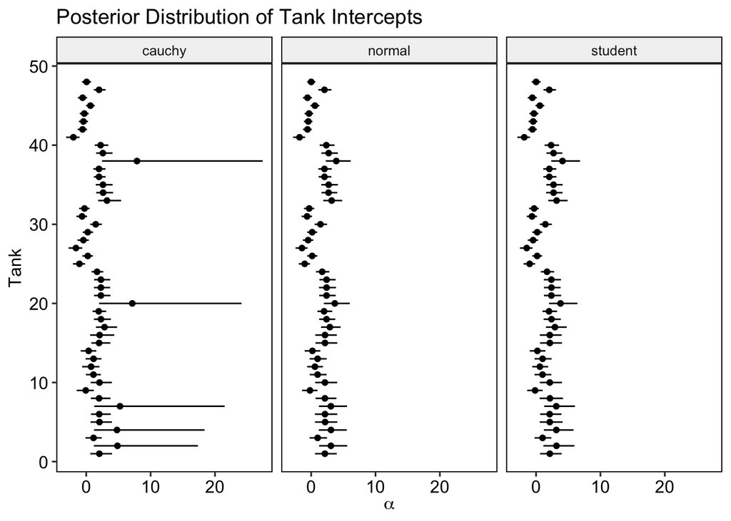

```r
###-- Put them together
res <-
  bind_rows("cauchy" = coefs_m_cauchy,
            "normal" = coefs_m_normal,
            "student" = coefs_m_student,
          .id = "prior")

###-- Plot
res |>
  ggplot(aes(mean, tank)) +
  geom_point() +
  geom_linerange(aes(xmin = low_95, xmax = high_95)) +
  labs(title = "Posterior Distribution of Tank Intercepts",
       x = expression(alpha),
       y = "Tank") +
  facet_wrap(~ prior)
```

Now the normal and the student-t look about the same, but let’s compare them more closely:

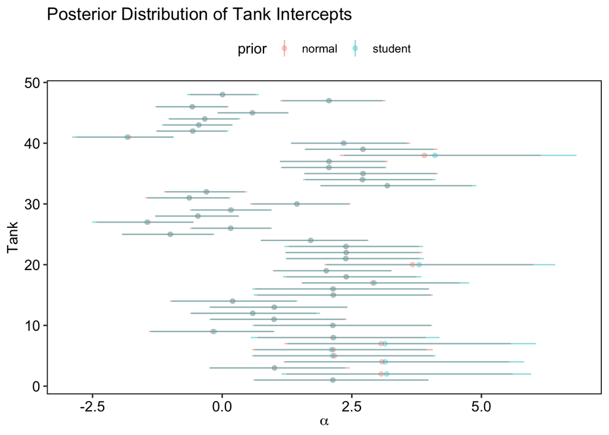

```r
res |>
  filter(prior != "cauchy") |>
  ggplot(aes(mean, tank, color = prior)) +
  geom_point(alpha = .3) +
  geom_linerange(aes(xmin = low_95, xmax = high_95), alpha = .5) +
  labs(title = "Posterior Distribution of Tank Intercepts",
       x = expression(alpha),
       y = "Tank")
```

```r
  facet_wrap(~ prior)
```

[output not shown]

Although it is subtle, for the largest intercepts there is less shrinkage with the t distribution than with the Gaussian, which is what we would expect.

The issue is that with brms I am not sure you can modify the v parameter of the t distribution (it should be somewhere here by I can’t seem to find it https://github.com/paul-buerkner/brms/issues/231), so I’ll do ulam as well with v = 2.

```r
m_s <-
  ulam(
    alist(
      S ~ dbinom(N,p),
      logit(p) <- a[tank],
      a[tank] ~ dstudent(2, a_bar,sigma),
      a_bar ~ dnorm(0,1.5),
      sigma ~ dexp(1)),
    data = data,
    chains = 4,
    log_lik = TRUE)


###--- Extract coefficients
coef_m_s <- precis(m_s,depth = 2,prob = .95)
```

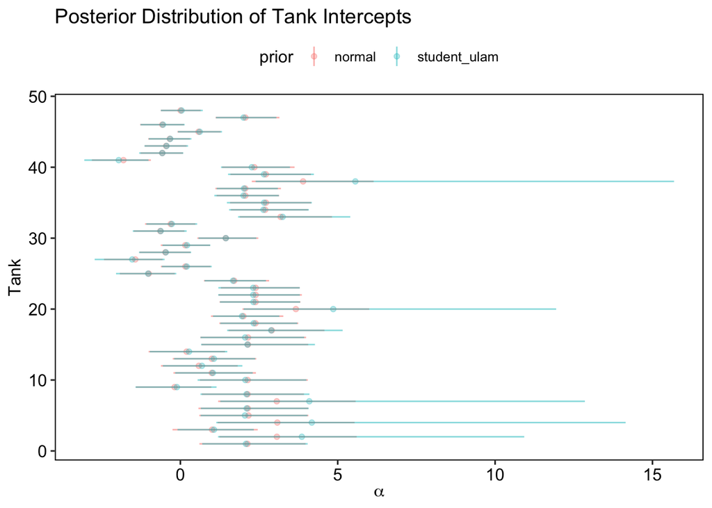

```r
###--- Put them in a tibble
coefs_m_student_ulam <-
  bind_cols(coef_m_s[1:6])  |>
    as_tibble() |>
    clean_names() |>
    mutate(tank = row.names(coef_m_s)) |>
  filter(str_detect(tank, "[1-9]+") == TRUE) |>  # Filter tank intercetps
  mutate(tank = as.integer(str_remove_all(tank,"\\[|\\]|a"))) |>
  rename(low_95 = x2_5_percent, high_95 = x97_5_percent)

res <-
  bind_rows("cauchy" = coefs_m_cauchy,
            "normal" = coefs_m_normal,
            "student_brms" = coefs_m_student,
            "student_ulam" = coefs_m_student_ulam,
          .id = "prior")


###-- Plot
res |>
  filter(prior %in% c("normal","student_ulam")) |>
  ggplot(aes(mean, tank, color = prior)) +
  geom_point(alpha = .3) +
  geom_linerange(aes(xmin = low_95, xmax = high_95), alpha = .5) +
  labs(title = "Posterior Distribution of Tank Intercepts",
       x = expression(alpha),
       y = "Tank")
```

Now we can see more differences, but in the same direction. Less shrinkage with the student-t distribution.

#### 13M5

Again this stuff is more difficul with brms so I use ulam:

```r
###--- Orignal model from the book
data(chimpanzees)

 d <- chimpanzees
 d$treatment <-1+d$prosoc_left+2*d$condition
 dat_list <-list(
  pulled_left =d$pulled_left,
  actor =d$actor,
  block_id =d$block,
  treatment =as.integer(d$treatment))

set.seed(13)

m13_4 <-ulam(
  alist(

  pulled_left ~ dbinom(1,p),
  logit(p) <- a[actor]+g[block_id]+b[treatment],
  b[treatment] ~ dnorm(0,0.5),

  ## adaptive priors
  a[actor] ~ dnorm(a_bar,sigma_a),
  g[block_id] ~ dnorm(0,sigma_g),

  ## hyper-priors
  a_bar ~ dnorm(0,1.5),
  sigma_a ~ dexp(1),
  sigma_g ~ dexp(1)),

  data = dat_list,
  chains = 4,
  cores = 4,
  log_lik = TRUE)
```

```r
###--- Modified version of the model

m13_4b <-ulam(
  alist(

  pulled_left ~ dbinom(1,p),
  logit(p) <- a[actor]+g[block_id]+b[treatment],
  b[treatment] ~ dnorm(0,0.5),

  ## adaptive priors
  a[actor] ~ dnorm(a_bar,sigma_a),
  g[block_id] ~ dnorm(g_bar,sigma_g),

  ## hyper-priors
  a_bar ~ dnorm(0,1.5),
  g_bar ~ dnorm(0,1.5),
  sigma_a ~ dexp(1),
  sigma_g ~ dexp(1)),

  data = dat_list,
  chains = 4,
  cores = 4,
  log_lik = TRUE)
```

```r
###--- Display Results
precis(m13_4)
```

```
##              mean        sd        5.5%     94.5%     n_eff    Rhat4
## a_bar   0.6014632 0.7452654 -0.56767373 1.7480839  867.2054 1.004924
## sigma_a 2.0260519 0.6691123  1.20877503 3.2321398 1030.2236 1.004084
## sigma_g 0.2030002 0.1653719  0.02706031 0.4955708  276.1293 1.012830
```

```r
precis(m13_4b)
```

```
##               mean        sd        5.5%    94.5%     n_eff    Rhat4
## a_bar    0.3592809 0.9894059 -1.27202242 1.991276 246.15168 1.026664
## g_bar   -0.0340243 1.0495874 -1.39373307 1.923532  11.85594 1.165980
## sigma_a  2.1023988 0.6094908  1.23472602 3.139380 349.31764 1.018775
## sigma_g  0.1935959 0.1573930  0.03554254 0.486384   6.44616 1.235289
```

#### 13M6

```r
data <- list(y = rep(0,2))

###--- Model 1
m_weird_1 <- ulam(
  alist(
  y ~ dnorm(mu,1),
  mu ~ dnorm(10,1)),
  data = data,
  chains = 4,
  log_lik = TRUE)

###--- Model 2
m_weird_2 <- ulam(
  alist(
  y ~ dnorm(mu,1),
  mu ~ dstudent(2,10,1)),
  data = data,
  chains = 4,
  log_lik = TRUE)

###--- Model 3
m_weird_3 <- ulam(
  alist(
  y ~ dstudent(2,mu,1),
  mu ~ dnorm(10,1)),
  data = data,
  chains = 4,
  log_lik = TRUE)

###--- Model 4
m_weird_4 <- ulam(
  alist(
  y ~ dstudent(2,mu,1),
  mu ~ dstudent(2,10,1)),
  data = data,
  chains = 4,
  log_lik = TRUE)
```

```r
###--- Compare the models
 list("NN" = precis(m_weird_1)[1:6],
     "NS" = precis(m_weird_2)[1:6],
     "SN" = precis(m_weird_3)[1:6],
     "SS" = precis(m_weird_4)[1:6]) |>
  bind_rows(.id = "model") |>
  as_tibble() |>
  kable(format = "html",digits = 2) |>
  kable_styling()
```

| model | mean | sd | 5.5% | 94.5% | n_eff | Rhat4 |
| --- | --- | --- | --- | --- | --- | --- |
| NN | 3.31 | 0.56 | 2.37 | 4.17 | 532.97 | 1.00 |
| NS | 0.15 | 0.72 | -1.01 | 1.31 | 608.16 | 1.01 |
| SN | 9.37 | 1.04 | 7.81 | 11.04 | 731.58 | 1.00 |
| SS | 0.39 | 1.43 | -0.95 | 2.15 | 198.77 | 1.02 |

The prior $\mu \sim Normal(10,1)$ is too restrictive to let the model to find the right answer. Using t distribution as prior, with longer tails, allows the model to find the right answer even when then mean of the prior is so far from the true value as in this case.